# P8_Nonlinear Regression_Kyuri

Kyuri Park

October 24, 2022

# Introduction

First, load the packages:

```r
library(MASS)
library(splines)
library(ISLR)
library(tidyverse)
library(magrittr)
```

First, we specify a seed as usual.

```r
set.seed(123)
```

# Prediction plot

```r
data(Boston)
```

## 1. Create a function called `pred_plot()` that takes as input an `lm` object, which outputs the above plot but with a prediction line generated from the model object using the `predict()` method.

```r
pred_plot <- function(lm.obj) {
  # first create predictions for all values of lstat
  x_pred <- seq(min(Boston$lstat), max(Boston$lstat), length.out = 500)
  y_pred <- predict(lm.obj, newdata = data.frame(lstat = x_pred))

  # then create a ggplot object with a line based on those predictions
  Boston %>%
    ggplot(aes(x = lstat, y = medv)) +
    geom_point() +
    geom_line(data = tibble(lstat = x_pred, medv = y_pred), size = 1, col = "skyblue") +
    theme_minimal()
}
```

## 2. Create a linear regression object called `lin_mod` which models `medv` as a function of `lstat`. Check if your prediction plot works by running `pred_plot(lin_mod)`. Do you see anything out of the ordinary with the predictions?

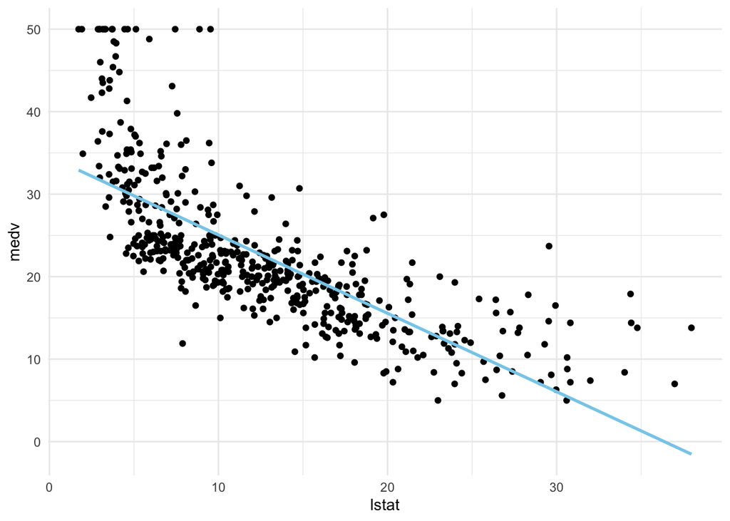

```r
lin_mod <- lm(medv ~ lstat, data = Boston)
pred_plot(lin_mod)
```

# Polynomial regression

## 3. Create another linear model `pn3_mod`, where you add the second and third-degree polynomial terms `I(lstat^2)` and `I(lstat^3)` to the formula. Create a `pred_plot()` with this model.

```r
pn3_mod <- lm(medv ~ lstat + I(lstat^2) + I(lstat^3), data = Boston)
pred_plot(pn3_mod)
```

[output not shown]

## 4. Play around with the poly() function. What output does it generate with the arguments `degree = 3` and `raw = TRUE`?

```r
poly(1:10, degree = 3, raw = TRUE)
```

```
       1   2    3
 [1,]  1   1    1
 [2,]  2   4    8
 [3,]  3   9   27
 [4,]  4  16   64
 [5,]  5  25  125
 [6,]  6  36  216
 [7,]  7  49  343
 [8,]  8  64  512
 [9,]  9  81  729
[10,] 10 100 1000
attr(,"degree")
[1] 1 2 3
attr(,"class")
[1] "poly"   "matrix"
```

```r
poly(1:10, degree = 3, raw = FALSE)
```

```
                1           2          3
 [1,] -0.49543369  0.52223297 -0.4534252
 [2,] -0.38533732  0.17407766  0.1511417
 [3,] -0.27524094 -0.08703883  0.3778543
 [4,] -0.16514456 -0.26111648  0.3346710
 [5,] -0.05504819 -0.34815531  0.1295501
 [6,]  0.05504819 -0.34815531 -0.1295501
 [7,]  0.16514456 -0.26111648 -0.3346710
 [8,]  0.27524094 -0.08703883 -0.3778543
 [9,]  0.38533732  0.17407766 -0.1511417
[10,]  0.49543369  0.52223297  0.4534252
attr(,"coefs")
attr(,"coefs")$alpha
[1] 5.5 5.5 5.5

attr(,"coefs")$norm2
[1]    1.0   10.0   82.5  528.0 3088.8

attr(,"degree")
[1] 1 2 3
attr(,"class")
[1] "poly"   "matrix"
```

```r
?poly
```

## 5. Use the poly() function directly in the model formula to create a 3rd-degree polynomial regression predicting `medv` using `lstat`. Compare the prediction plot to the previous prediction plot you made. What happens if you change the poly() function to `raw = FALSE`?

```r
# raw = TRUE
pn3_mod2_true <- lm(medv ~ poly(lstat, 3, raw = TRUE), data = Boston)
pred_plot(pn3_mod2_true)
```

[output not shown]

```r
# raw = FALSE
pn3_mod2_false <- lm(medv ~ poly(lstat, 3, raw = FALSE), data = Boston)
pred_plot(pn3_mod2_false)
```

[output not shown]

# Piecewise regression

## 6. Create a model called `pw2_mod` with one predictor: `I(lstat <= median(lstat))`. Create a pred_plot with this model. Use the coefficients in `coef(pw2_mod)` to find out what the predicted value for a low-lstat neighbourhood is.

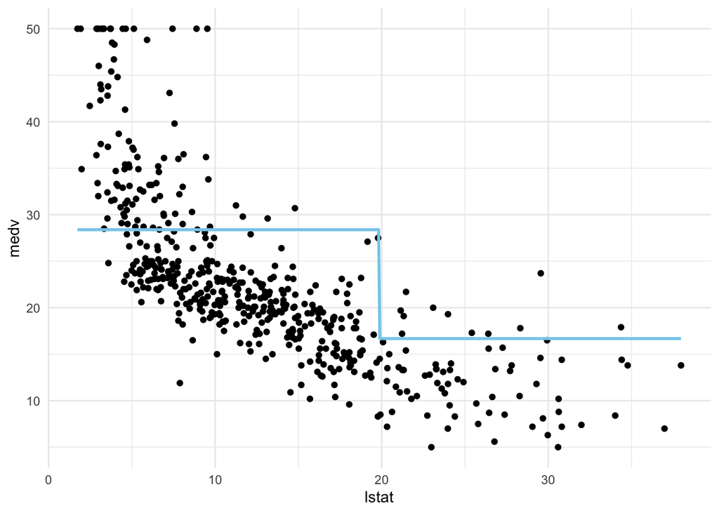

```r
pw2_mod <- lm(medv ~ I(lstat <= median(lstat)), data = Boston)
pred_plot(pw2_mod)
```

```r
coef(pw2_mod)
```

```
                  (Intercept) I(lstat <= median(lstat))TRUE
                     16.67747                      11.71067
```

## 7. Use the `cut()` function in the formula to generate a piecewise regression model called `pw5_mod` that contains 5 equally spaced sections. Again, plot the result using `pred_plot`.

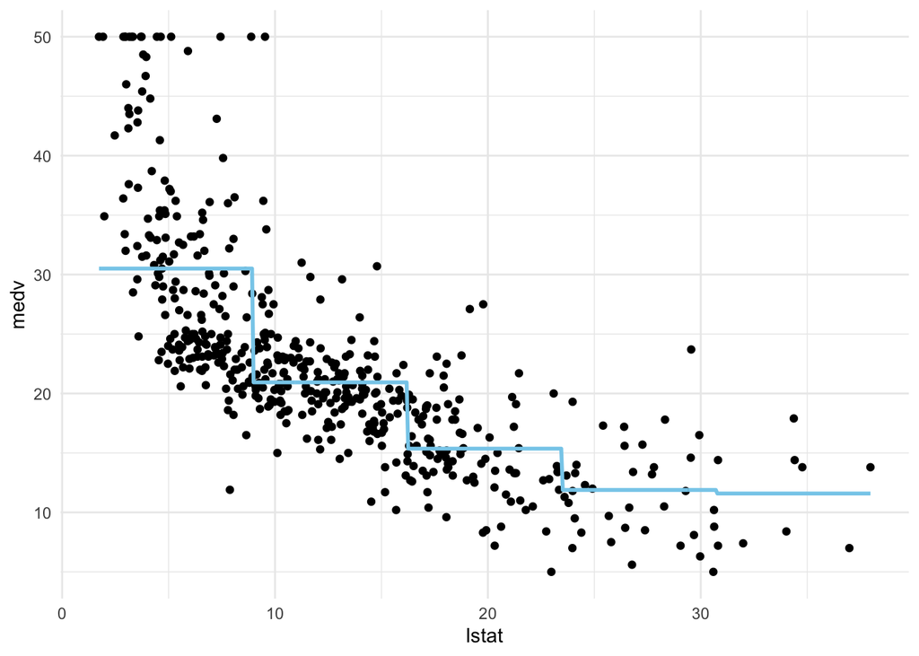

```r
pw5_mod <- lm(medv ~ cut(lstat, 5), data = Boston)
pred_plot(pw5_mod)
```

## 8. Optional: Create a piecewise regression model `pwq_mod` where the sections are not equally spaced, but have equal amounts of training data. Hint: use the `quantile()` function.

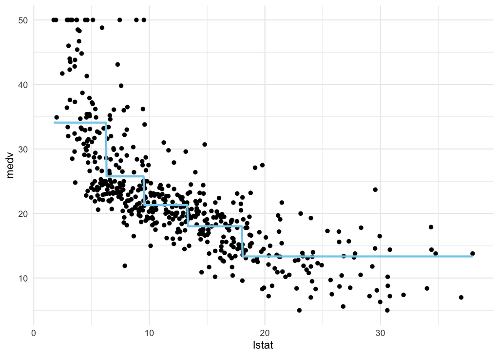

```r
brks <- c(-Inf, quantile(Boston$lstat, probs = c(.2, .4, .6, .8)), Inf)
pwq_mod <- lm(medv ~ cut(lstat, brks), data = Boston)
pred_plot(pwq_mod)
```

# Piecewise polynomial regression

9. This function does not have comments. Copy - paste the function and add comments to each line. To figure out what each line does, you can first create “fake” `vec` and `knots` variables, for example `vec <- 1:20` and `knots <- 2` and try out the lines separately.

```r
piecewise_cubic_basis <- function(vec, knots = 1) {
  # if knots is 0 then just return the 3rd order polynomial
  if (knots == 0) return(poly(vec, degree = 3, raw = TRUE))
  # cut the vector in the number of knots + 1
  cut_vec <- cut(vec, breaks = knots + 1)
  # matrix storage
  out <- matrix(nrow = length(vec), ncol = 0)
  # loop over the levels of the cut vector
  for (lvl in levels(cut_vec)) {
    # temporary storage
    tmp <- vec
    # set all values to zero except for the current looping value
    tmp[cut_vec != lvl] <- 0
    # append the polynomial based on this vector to the matrix
    out <- cbind(out, poly(tmp, degree = 3, raw = TRUE))
  }

  out
}
```

## 10. Create piecewise cubic models with 1, 2, and 3 knots (`pc1_mod` - `pc3_mod`) using this piecewise cubic basis function. Compare them using the `pred_plot()` function.

```r
pc1_mod <- lm(medv ~ piecewise_cubic_basis(lstat, 1), data = Boston)
pc2_mod <- lm(medv ~ piecewise_cubic_basis(lstat, 2), data = Boston)
pc3_mod <- lm(medv ~ piecewise_cubic_basis(lstat, 3), data = Boston)

pred_plot(pc1_mod)
```

[output not shown]

```r
pred_plot(pc1_mod)
```

[output not shown]

```r
pred_plot(pc1_mod)
```

[output not shown]

# Splines

## 11. Create a data frame called `boston_tpb` with the columns `medv` and `lstat` from the `Boston` dataset.

```r
boston_tpb <- Boston %>% select(medv, lstat)
```

## 12. Now use `mutate` to add squared and cubed versions of the `lstat` variable to this dataset.

```r
boston_tpb %<>%
  mutate(lstat2 = (lstat)^2, lstat3 = (lstat)^3)
```

## 13. Use `mutate` to add a column `lstat_tpb` to this dataset which is 0 below the median and has value `(lstat - median(lstat))^3` above the median. Tip: you may want to use `ifelse()` within your `mutate()` call.

```r
boston_tpb %<>%
  mutate(lstat_tpb = ifelse(lstat > median(lstat), (lstat - median(lstat))^3, 0))
```

## 14. Create a linear model `tpb_mod` using the `lm()` function. How many predictors are in the model? How many degrees of freedom does this model have?

```r
tpb_mod <- lm(medv ~ ., data = boston_tpb)
summary(tpb_mod)
```

```
Call:
lm(formula = medv ~ ., data = boston_tpb)

Residuals:
     Min       1Q   Median       3Q      Max
-13.5106  -3.0547  -0.7488   2.1178  27.1383

Coefficients:
              Estimate Std. Error t value Pr(>|t|)
(Intercept)  65.514246   3.054303  21.450  < 2e-16 ***
lstat       -10.324275   1.089886  -9.473  < 2e-16 ***
lstat2        0.856576   0.116108   7.377 6.75e-13 ***
lstat3       -0.025484   0.003810  -6.688 6.05e-11 ***
lstat_tpb     0.026582   0.004291   6.194 1.22e-09 ***
---
Signif. codes:  0 '***' 0.001 '**' 0.01 '*' 0.05 '.' 0.1 ' ' 1

Residual standard error: 5.206 on 501 degrees of freedom
Multiple R-squared:  0.6822,    Adjusted R-squared:  0.6796
F-statistic: 268.8 on 4 and 501 DF,  p-value: < 2.2e-16
```

```r
nrow(boston_tpb)
```

```
[1] 506
```

## 15. Create a cubic spline model `bs1_mod` with a knot at the median using the `bs()` function. Compare its predictions to those of the `tpb_mod` using the `predict()` function on both models.

```r
bs1_mod <- lm(medv ~ bs(lstat, knots = median(lstat)), data =Boston)

# Comparing the predictions from the two models: negligible absolute difference
mean(abs(predict(bs1_mod) - predict(tpb_mod)))
```

```
[1] 3.160511e-13
```

## 16. Create a prediction plot from the `bs1_mod` object using the `plot_pred()` function.

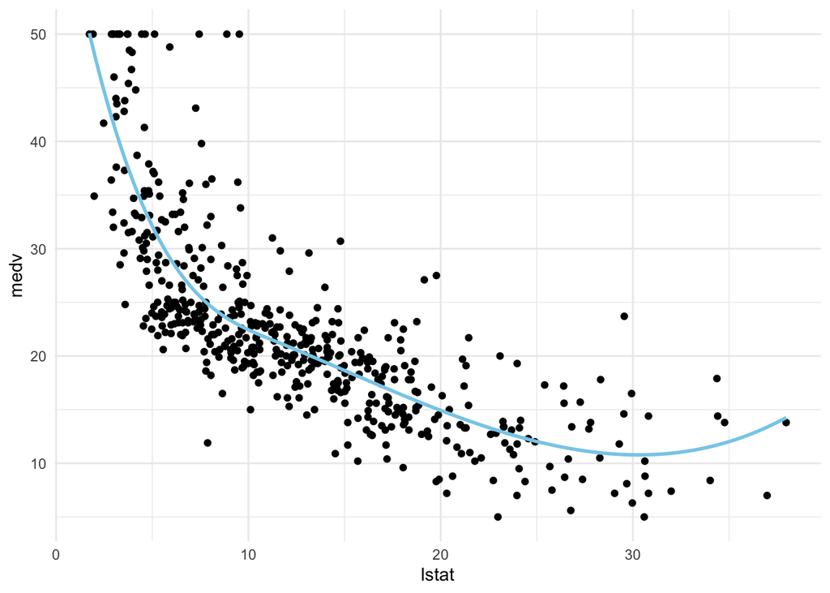

```r
pred_plot(bs1_mod)
```

## 17. Create a natural cubic spline model (`ns3_mod`) with 3 degrees of freedom using the `ns()` function. Plot it, and compare it to the `bs1_mod`.

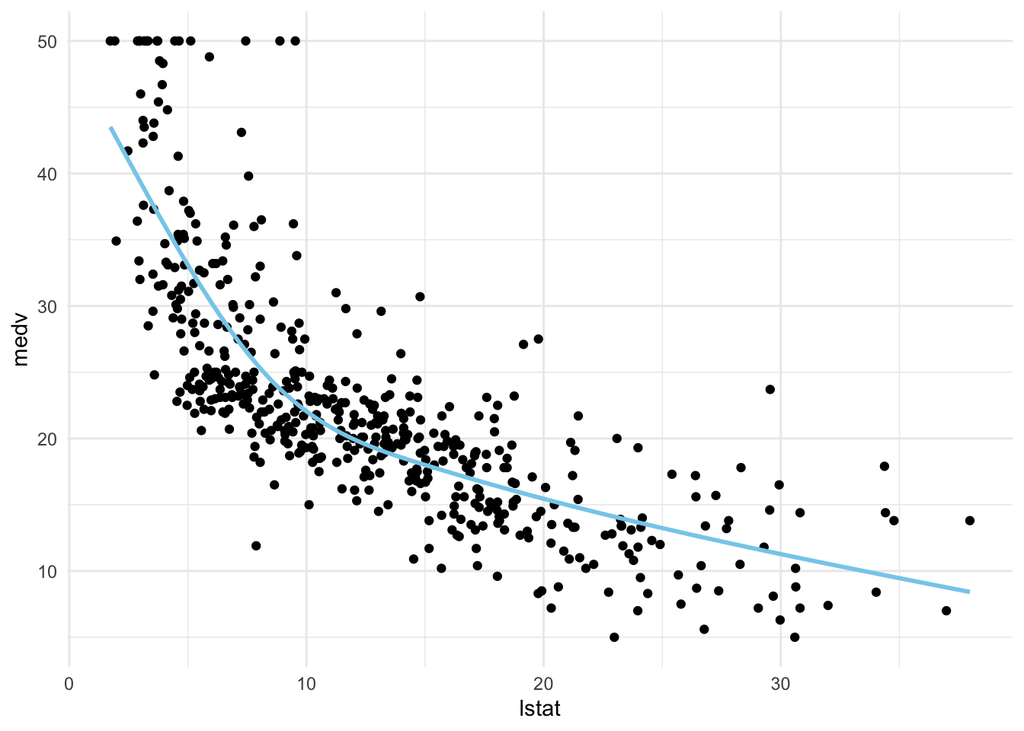

```r
ns3_mod <- lm(medv ~ ns(lstat, df = 3), data = Boston)
pred_plot(ns3_mod)
```

## 18. Plot `lin_mod`, `pn3_mod`, `pw5_mod`, `pc3_mod`, `bs1_mod`, and `ns3_mod` and give them nice titles by adding `+ ggtitle("My title")` to the plot. You may use the function `plot_grid()` from the package `cowplot` to put your plots in a grid.

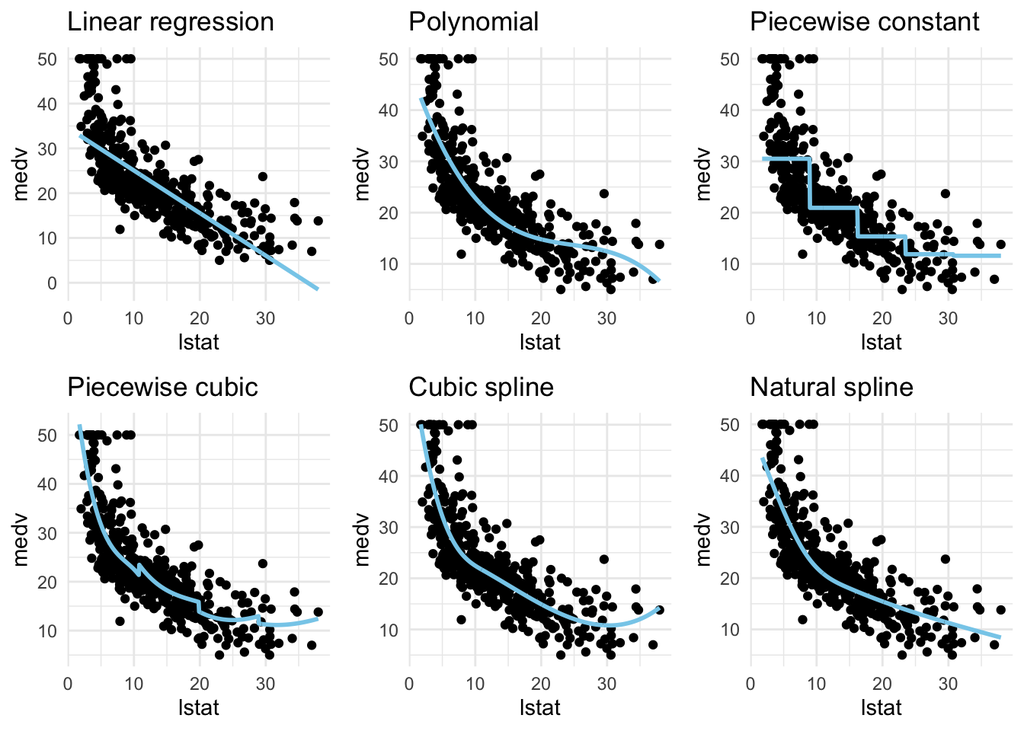

```r
library(cowplot)

plot_grid(
  pred_plot(lin_mod) + ggtitle("Linear regression"),
  pred_plot(pn3_mod) + ggtitle("Polynomial"),
  pred_plot(pw5_mod) + ggtitle("Piecewise constant"),
  pred_plot(pc3_mod) + ggtitle("Piecewise cubic"),
  pred_plot(bs1_mod) + ggtitle("Cubic spline"),
  pred_plot(ns3_mod) + ggtitle("Natural spline")
)
```